# NLP_project_2_Maneesh

```python
news.info()
```

```
<class 'pandas.core.frame.DataFrame'>
RangeIndex: 28619 entries, 0 to 28618
Data columns (total 3 columns):
 #   Column        Non-Null Count  Dtype
---  ------        --------------  -----
 0   is_sarcastic  28619 non-null  int64
 1   headline      28619 non-null  object
 2   article_link  28619 non-null  object
dtypes: int64(1), object(2)
memory usage: 670.9+ KB
```

```python
# check for null/nan- invalid values
news.isna().sum()
```

```
is_sarcastic    0
headline        0
article_link    0
dtype: int64
```

```python
# check for sentiment classes
news.is_sarcastic.value_counts()
```

```
0    14985
1    13634
Name: is_sarcastic, dtype: int64
```

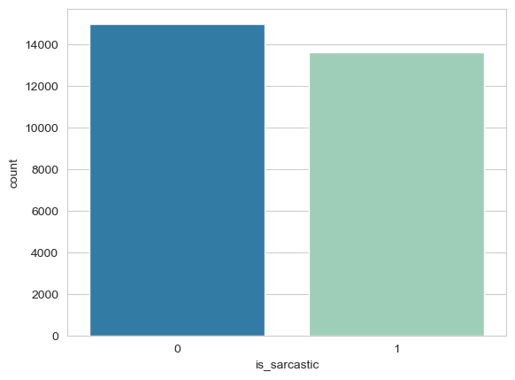

```python
#Plot for is_sarcastic
sns.set_style('whitegrid')
sns.countplot(x='is_sarcastic',data=news, palette='YlGnBu_r');
```

2. Retain relevant columns

```python
#Deep copying the dataframe
df=news.copy(deep= True)
```

```python
# Since we are planning to use only headline to detect sarcasm, we can remove the link to the article from dataframe
df.drop(["article_link"],axis=1,inplace=True)
```

3. Get length of each sentence

```python
df['length of sentence'] = df.headline.apply(lambda x: len(str(x).split(' ')))
df.head()
```

|  | is_sarcastic | headline | length of sentence |
| --- | --- | --- | --- |
| 0 | 1 | thirtysomething scientists unveil doomsday clo... | 8 |
| 1 | 0 | dem rep. totally nails why congress is falling... | 13 |
| 2 | 0 | eat your veggies: 9 deliciously different recipes | 7 |
| 3 | 1 | inclement weather prevents liar from getting t... | 8 |
| 4 | 1 | mother comes pretty close to using word 'strea... | 9 |

4. Define parameters

5. Get indices for words

6. Create features and labels

```python
# remove unwanted characters but keep the alphanum
pattern = "[^\w ]"
df.headline = df.headline.apply(lambda s : re.sub(pattern,"",s))
```

```python
#covert all texts in text columns into lower case
df.headline = df.headline.apply(lambda s: s.lower())
```

```python
#remove unwanted spaces
df.headline = df.headline.apply(lambda s: s.strip())
```

```python
from nltk.corpus import stopwords
nltk.download('stopwords')
```

```
True
```

```python
stopwords = set(stopwords.words('english'))
df.headline = df.headline.apply(lambda x: ' '.join([word for word in x.split() if word not in stopwords]))
#recheck data
df.head()
```

|  | is_sarcastic | headline | length of sentence |
| --- | --- | --- | --- |
| 0 | 1 | thirtysomething scientists unveil doomsday clo... | 8 |
| 1 | 0 | dem rep totally nails congress falling short g... | 13 |
| 2 | 0 | eat veggies 9 deliciously different recipes | 7 |
| 3 | 1 | inclement weather prevents liar getting work | 8 |
| 4 | 1 | mother comes pretty close using word streaming... | 9 |

```python
#creatin feature labels

X=df['headline'].values
y=df['is_sarcastic'].values
X_train, X_test, y_train, y_test = train_test_split(X, y, test_size=0.30, random_state=42)
```

```python
#Define parameters, Tokenize and get indices for words
vocab_size=10000
embedding_dim=100
max_length=32
trunc_type='post'
padding_type='post'
oov_tok=''
from tensorflow.keras.preprocessing.text import Tokenizer
from tensorflow.keras.preprocessing.sequence import pad_sequences
tokenizer= Tokenizer(num_words=vocab_size, oov_token=oov_tok)
tokenizer.fit_on_texts(X_train)
word_index=tokenizer.word_index
training_sequences=tokenizer.texts_to_sequences(X_train)
training_padded=pad_sequences(training_sequences, maxlen=max_length, padding=padding_type, truncating=trunc_type)
testing_sequences=tokenizer.texts_to_sequences(X_test)
testing_padded=pad_sequences(testing_sequences, maxlen=max_length, padding=padding_type, truncating=trunc_type)
```

```python
#Building a dense network first
model = Sequential()
model.add(Embedding(vocab_size, embedding_dim, input_length=max_length))
model.add(Flatten())
model.add(Dense(units=32,activation='relu'))
model.add(Dropout(0.5))
model.add(Dense(units=10,activation='relu'))
model.add(Dropout(0.5))
model.add(Dense(units=1,activation='sigmoid'))
opt = keras.optimizers.Adam(learning_rate=0.0001)
model.compile(loss='binary_crossentropy', optimizer=opt, metrics=['accuracy'])
model.summary()
```

```
Model: "sequential_1"
_________________________________________________________________
 Layer (type)                Output Shape              Param #
=================================================================
 embedding_1 (Embedding)     (None, 32, 100)           1000000

 flatten (Flatten)           (None, 3200)              0

 dense_2 (Dense)             (None, 32)                102432

 dropout (Dropout)           (None, 32)                0

 dense_3 (Dense)             (None, 10)                330

 dropout_1 (Dropout)         (None, 10)                0

 dense_4 (Dense)             (None, 1)                 11

=================================================================
Total params: 1102773 (4.21 MB)
Trainable params: 1102773 (4.21 MB)
Non-trainable params: 0 (0.00 Byte)
_________________________________________________________________
```

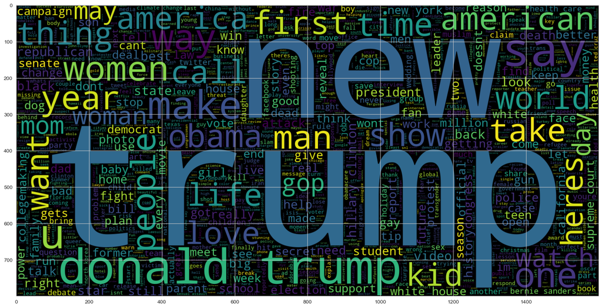

```python
plt.figure(figsize = (20,20))
wc = WordCloud(max_words = 2000 , width = 1600 , height = 800).generate(" ".join(df[df.is_sarcastic == 0].headline))
plt.imshow(wc , interpolation = 'bilinear')
```

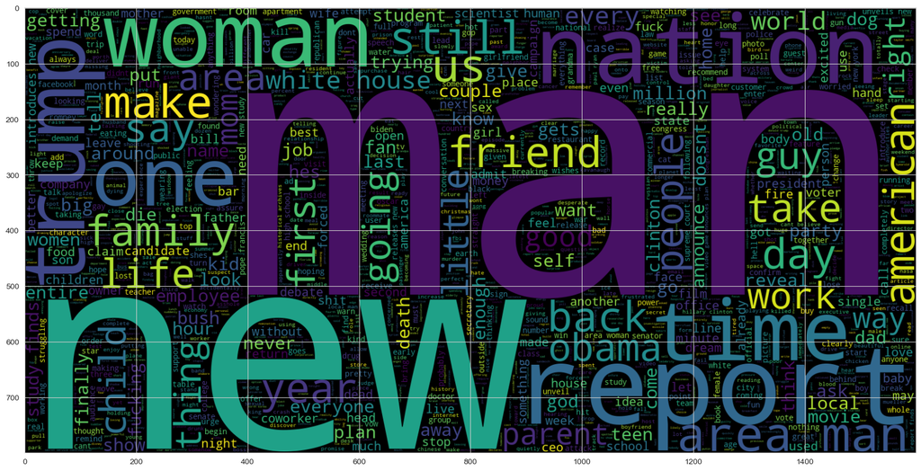

```python
plt.figure(figsize = (20,20))
wc = WordCloud(max_words = 2000 , width = 1600 , height = 800).generate(" ".join(df[df.is_sarcastic == 1].headline))
plt.imshow(wc , interpolation = 'bilinear')
```

7. Get vocabulary size

8. Create a weight matrix using GloVe embeddings

```python
vocab = set()
wordCount = 0
def wCount(doc):
    global wordCount,vocab
    doc = doc.split()
    vocab.update(doc)
    wordCount+=len(doc)

tqdm.pandas(desc="wordCount")
news.headline.progress_apply(lambda x: wCount(x));
```

```python
# counts
len(vocab),wordCount
```

```
(38234, 287620)
```

```python
!mkdir -p dense_model_output
```

[output not shown]

```python
os.chdir('C:\\Users\\maneeshkumar\\Documents\\AI ML\\NLP Project\\')
```

```python
%pwd
%ls
```

[output not shown]

```python
import zipfile

with zipfile.ZipFile('glove.6B.zip', 'r') as zip_ref:
    zip_ref.extractall()
```

```python
glove_dir = 'C:\\Users\\maneeshkumar\\Documents\\AI ML\\NLP Project\\'
embeddings_index = {}
with open(os.path.join(glove_dir, 'glove.6B.100d.txt'), encoding='utf-8') as f:
    for line in f:
        values = line.split()
        word = values[0]
        coefs = np.asarray(values[1:], dtype='float32')
        embeddings_index[word] = coefs

print('Found %s word vectors.' % len(embeddings_index))
```

```
Found 400000 word vectors.
```

```python
embedding_dim = 100
embedding_matrix = np.zeros((vocab_size, embedding_dim))
for word, i in word_index.items():
  if i<vocab_size:
    embedding_vector = embeddings_index.get(word)
    if embedding_vector is not None:
      embedding_matrix[i] = embedding_vector
```

```python
#Adding the weights from the glove embedding
model.layers[0].set_weights([embedding_matrix])
model.layers[0].trainable = False
```

```python
early_stop = EarlyStopping(monitor='val_loss', mode='min', verbose=1, patience=5)
model.fit(x=training_padded, y=y_train, batch_size=256, epochs=100, validation_data=(testing_padded, y_test), verbose=1, callbacks=[early_stop])
```

```
Epoch 44: early stopping
```

```
<keras.src.callbacks.History at 0x2483ad72610>
```

```python
import pandas as pd

df_m = pd.DataFrame(model.history.history)
df_m.reset_index(drop=True, inplace=True)
df_m['Epoch'] = range(1, len(df_m) + 1)

df_m.set_index('Epoch', inplace=True)
```

```python
score = model.evaluate(testing_padded, y_test, batch_size=64, verbose=1)
print('Test accuracy:', score[1])
```

```
Test accuracy: 0.7987421154975891
```

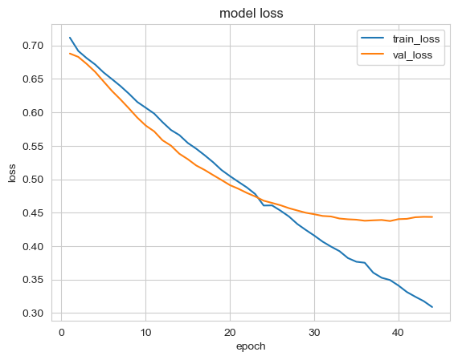

```python
#Loss Graph(Training and Validation)
plt.plot(df_m['loss'])
plt.plot(df_m['val_loss'])
plt.title('model loss')
plt.ylabel('loss')
plt.xlabel('epoch')
plt.legend(['train_loss', 'val_loss'])
plt.show()
```

```python
#building CNN model
model_conv = Sequential([
    Embedding(vocab_size, embedding_dim, input_length=max_length),
    Conv1D(16,3,activation='relu'),
    MaxPooling1D(2),
    Dropout(0.2),
    Flatten(),
    Dense(6, activation='relu'),
    Dense(1, activation='sigmoid')
])
```

```python
model_conv.summary()
```

```
Model: "sequential_2"
_________________________________________________________________
 Layer (type)                Output Shape              Param #
=================================================================
 embedding_2 (Embedding)     (None, 32, 100)           1000000

 conv1d (Conv1D)             (None, 30, 16)            4816

 max_pooling1d (MaxPooling1  (None, 15, 16)            0
 D)

 dropout_2 (Dropout)         (None, 15, 16)            0

 flatten_1 (Flatten)         (None, 240)               0

 dense_5 (Dense)             (None, 6)                 1446

 dense_6 (Dense)             (None, 1)                 7

=================================================================
Total params: 1006269 (3.84 MB)
Trainable params: 1006269 (3.84 MB)
Non-trainable params: 0 (0.00 Byte)
_________________________________________________________________
```

```python
model_conv.layers[0].set_weights([embedding_matrix])
model_conv.layers[0].trainable = False
model_conv.compile(loss='binary_crossentropy',optimizer='adam',metrics=['accuracy'])
history=model_conv.fit(training_padded, y_train, batch_size=256, epochs=20, validation_data=(testing_padded, y_test), callbacks=[early_stop])
```

[output not shown]

9. Define and compile a Bidirectional LSTM model.

```python
model_lstm = Sequential([
    Embedding(vocab_size, embedding_dim, input_length=max_length),
    keras.layers.Bidirectional(keras.layers.LSTM(32)),
    Dense(6, activation='relu'),
    Dense(1, activation='sigmoid')
])
```

```python
model_lstm.summary()
```

```
Model: "sequential_3"
_________________________________________________________________
 Layer (type)                Output Shape              Param #
=================================================================
 embedding_3 (Embedding)     (None, 32, 100)           1000000

 bidirectional (Bidirection  (None, 64)                34048
 al)

 dense_7 (Dense)             (None, 6)                 390

 dense_8 (Dense)             (None, 1)                 7

=================================================================
Total params: 1034445 (3.95 MB)
Trainable params: 1034445 (3.95 MB)
Non-trainable params: 0 (0.00 Byte)
_________________________________________________________________
```

```python
model_lstm.layers[0].set_weights([embedding_matrix])
model_lstm.layers[0].trainable = False
```

```python
model_lstm.compile(loss='binary_crossentropy',optimizer='adam',metrics=['accuracy'])
early_stop = EarlyStopping(monitor='val_loss', mode='min', verbose=1, patience=5)
```

10. Fit the model and check the validation accuracy

```python
history_lstm = model_lstm.fit(x=training_padded, y=y_train, batch_size=64, epochs=100, validation_data=(testing_padded, y_test), verbose=1, callbacks=[early_stop])
```

```
Epoch 11: early stopping
```

```python
score = model_lstm.evaluate(testing_padded, y_test, batch_size=64, verbose=1)
print('Test accuracy:', score[1])
```

```
Test accuracy: 0.7692755460739136
```

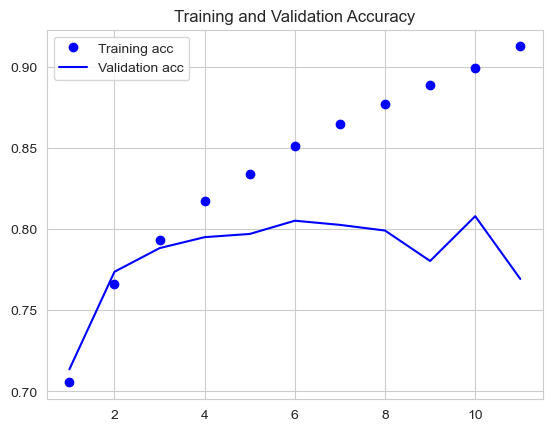

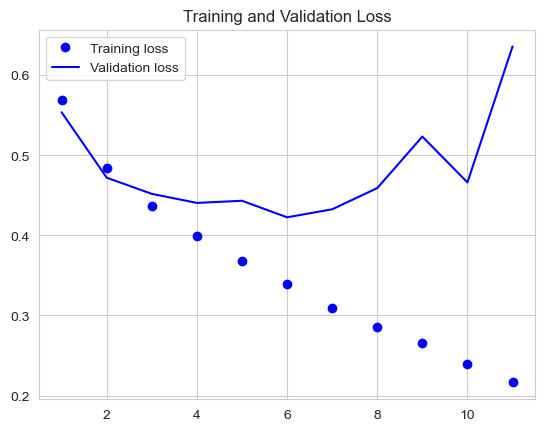

```python
acc = history_lstm.history['accuracy']
val_acc = history_lstm.history['val_accuracy']
loss = history_lstm.history['loss']
val_loss = history_lstm.history['val_loss']
epochs = range(1, len(acc) + 1)
plt.plot(epochs, acc, 'bo', label = 'Training acc')
plt.plot(epochs, val_acc, 'b', label = 'Validation acc')
plt.title('Training and Validation Accuracy')
plt.legend()
plt.figure()
plt.plot(epochs, loss, 'bo', label = 'Training loss')
plt.plot(epochs, val_loss, 'b', label = 'Validation loss')
plt.title('Training and Validation Loss')
plt.legend()
plt.show()
```

**This model did not perform good as compared to the other base models. One observable reason is that we only consider first 32 words for our inputs, rather than full sequences. Also we did not experiment much with the embedding dimensionality or the LSTM output. We also did not try with regularization. However, the major reason here is that analyzing the global long term structure of the reviews isn't helpful in solving the problem.**